# Práctica: Números reales y complejos en Python

Calcula la distancia a tu DNI del número más próximo. También la distancia del inverso (1/DNI) al número más próximo

```python
# Completar aquí

import numpy as np

DNI = 23982606

print(np.spacing(DNI))

print(np.spacing(1 / DNI))

# Fin Completar aquí ------------------------------------
```

```
3.725290298461914e-09
6.617444900424222e-24
```

Define una función que multiplique y divida $100$ veces a tu número de DNI el número $1/10$. Imprime en pantalla el valor resultante y ejecuta un operador booleano para averiguar si el valor obtenido coincide con tu DNI.

¿Obtienes tu DNI? ¿Por qué?

```python
# Completar aquí

def multiply_and_divide(iterations):
    result =  DNI

    for i in range(iterations):
        result *= 1 / 10

    for i in range(iterations):
        result /= 1 / 10
    return result

DNI_2 = {multiply_and_divide(100)}
print(f" DNI_2 = {DNI_2}")

DNI == DNI_2

# Fin Completar aquí ------------------------------------
```

```
 DNI_2 = {23982606.000000026}
```

```
False
```

Consider los números complejos $z_1 = a + bj$ y $z_2 = g + hj$. Calcula la forma polar de ambos números. Expresa la fase en grados

```python
# Completar aquí

import cmath
import numpy as np

z_1 = 2 + 3j
z_2 = 0 + 6j

w_1 = cmath.polar(z_1)
print(f"z_1 en forma polar = {w_1}")
print(f"Argumento en grados = {np.rad2deg(w_1[1])}")

w_2 = cmath.polar(z_2)
print(f"z_2 en forma polar = {w_2}")
print(f"Fase en grados = {np.rad2deg(w_2[1])}")

# Fin Completar aquí ------------------------------------
```

```
z_1 en forma polar = (3.605551275463989, 0.982793723247329)
Argumento en grados = 56.309932474020215
z_2 en forma polar = (6.0, 1.5707963267948966)
Fase en grados = 90.0
```

Realiza las siguientes operaciones usando ambos los módulos **cmath** y **numpy**:

$z_1 + z_2$, $z_1 - z_2$, $z_1 * z_2$, $z_1 / z_2$, $z_2^3$ y conjugado de $z_1$

```python
# Completar aquí
# cálculos con cmath
print(f"z_1 + z_2 = {z_1 + z_2}")
print(f"z_1 - z_2 = {z_1 - z_2}")
print(f"z_1 * z_2 = {z_1 * z_2}")
print(f"z_1 / z_2 = {z_1 / z_2}")
print(f"potencia 3 de z_2 = {z_2 ** 3}")
print(f"conjugado de z_1 = {z_1.conjugate()}")

# cálculos con numpy
print(f"z_1 + z_2 = {z_1 + z_2}")
print(f"z_1 - z_2 = {z_1 - z_2}")
print(f"z_1 * z_2 = {z_1 * z_2}")
print(f"z_1 / z_2 = {z_1 / z_2}")
print(f"potencia 3 de z_2 = {z_2 ** 3}")
print("conjugado de z_1 = ", np.conj(z_1))

# Fin Completar aquí ------------------------------------
```

```
z_1 + z_2 = (2+9j)
z_1 - z_2 = (2-3j)
z_1 * z_2 = (-18+12j)
z_1 / z_2 = (0.5-0.3333333333333333j)
potencia 3 de z_2 = (-0-216j)
conjugado de z_1 = (2-3j)
z_1 + z_2 = (2+9j)
z_1 - z_2 = (2-3j)
z_1 * z_2 = (-18+12j)
z_1 / z_2 = (0.5-0.3333333333333333j)
potencia 3 de z_2 = (-0-216j)
conjugado de z_1 =  (2-3j)
```

Introduce el número compelo $z = e^{2\pi j/ 8}$ y calcula $z^k$ para $1\leq k\leq 9$

¿Es $z = z^9$ ? ¿Por qué?

```python
# Completar aquí

w = complex(0, 2 * cmath.pi / 8)
z = cmath.exp(w)
print(f" z = {z}")
print(f"z^2 = {z ** 2}")
print(f"z^3 = {z ** 3}")
print(f"z^4 = {z ** 4}")
print(f"z^5 = {z ** 5}")
print(f"z^6 = {z ** 6}")
print(f"z^7 = {z ** 7}")
print(f"z^8 = {z ** 8}")
print(f"z^9 = {z ** 9}")

# Fin Completar aquí ------------------------------------
```

```
 z = (0.7071067811865476+0.7071067811865476j)
z^2 = 1.0000000000000002j
z^3 = (-0.7071067811865477+0.7071067811865477j)
z^4 = (-1.0000000000000004+0j)
z^5 = (-0.7071067811865479-0.7071067811865479j)
z^6 = (-0-1.0000000000000007j)
z^7 = (0.707106781186548-0.707106781186548j)
z^8 = (1.0000000000000009+0j)
z^9 = (0.7071067811865482+0.7071067811865482j)
```

Consideremos la función $f(t) = j \frac{1}{1 + t}e^{ j (t + \frac{\pi}{2})}, \quad 0\leq t\leq 4\pi .$

Se pide:

1) Calcula el módulo y la fase (o argumento principal) de $f(1)$.

2) Calcula la forma binómica de $f(1)$.

3) Calcula $\frac{1}{f(1)}$ y expresa el resultado en forma binómica.

4) Calcula $f^2(1)$ y $f(1) + \frac{1}{f(1)}$ y expresa el resultado en forma binómica.

5) Haz un gráfico de $f$, es decir representa en el eje $X$ la parte real de $f$ y en el eje $Y$ la parte imaginaria.

6) Haz un gráfico de $\text{Re}f(t)$ e $\text{Im}f(t)$.

```
módulo =  0.5
fase (argumento) (en radianes) =  -2.141592653589793
fase (argumento) (en grados) =  -122.70422048691768
forma binómica de f(1) =  (-0.2701511529340699-0.42073549240394825j)
1 / f(1) =  (-1.0806046117362795+1.682941969615793j)
f^2(1) =  (-0.10403670913678557+0.22732435670642046j)
f(1) + 1 / f(1) =  (-1.3507557646703494+1.2622064772118446j)
```

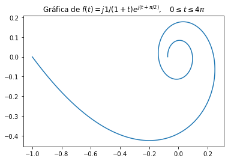

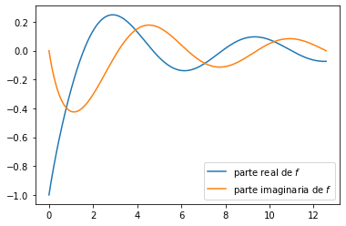

```python
# Completar aquí

# Módulo y fase de f(1)

z = complex(0, 1 + cmath.pi / 2 )
f_1 = 1j * 0.5 * cmath.exp(z)
print('módulo = ', np.abs(f_1))
print('fase (argumento) (en radianes) = ', np.angle(f_1))
print('fase (argumento) (en grados) = ', np.rad2deg(np.angle(f_1)))

# forma binómica de f(1)

print('forma binómica de f(1) = ', f_1)

# inverso de f(1)

print('1 / f(1) = ', 1 / f_1)

# f^2(1) y 1 + 1 / f(1)

print('f^2(1) = ', f_1 ** 2)
print('f(1) + 1 / f(1) = ', f_1 + (1 / f_1))

# Gráfica de f(t)

import matplotlib.pyplot as plt

t = np.linspace(0,  4 * np.pi, 1000)
f = 1j * (1 / (1 + t)) * np.exp( 1j * (t + np.pi / 2))

x = np.real(f)
y = np.imag(f)

fig, ax = plt.subplots()
ax.plot(x, y)
ax.set_title('Gráfica de $f(t) = j 1 / (1 + t) e^{ j (t + \pi / 2)}, \quad 0\leq t\leq 4\pi $')

plt.show()

# Gráficas de las parte real e imaginaria de $f$

fig, ax = plt.subplots()
ax.plot(t, x, label='parte real de $f$')
ax.plot(t, y, label='parte imaginaria de $f$')
ax.legend()

plt.show()

# Fin Completar aquí ------------------------------------
```